# Longitudinal Clustering

Applied Machine Learning in Economics

# Setup

Load the libraries `tidyverse`, `cluster`, and `readxl`. Set the seed to 490. Using `read_excel()`, load the data specifying the argument `sheet = 2`.

```r
library(tidyverse)
library(cluster)
library(readxl)
set.seed(490)

macro = read_excel('C:/Users/johnj/Documents/Data/macro history/JSTdatasetR4.xlsx', sheet = 2)

mh = macro %>%
  select(country, year, gdp, exports) %>%
  na.omit %>%
  mutate(exports_per_gdp = exports/gdp) %>%
  filter(year >= 1885 & !year %in% c(1914:1923, 1940:1947))
```

# EDA

Using `ggplot2`, plot the exports per GDP grouped by country. Which country and year is the maximum?

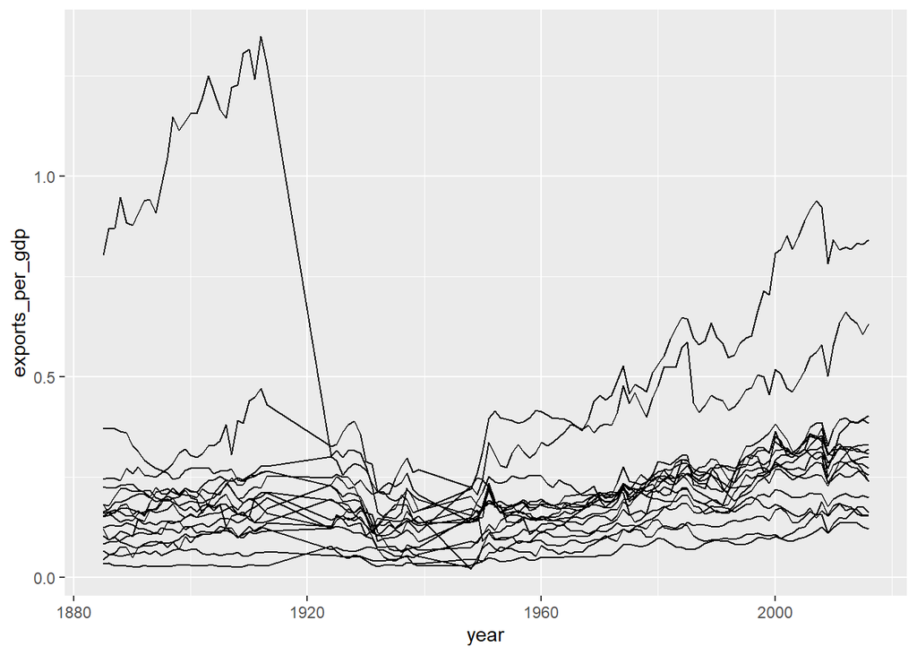

```r
ggplot(mh, aes(x = year, y = exports_per_gdp, group = country)) +
  geom_line()
```

```r
mh[which.max(mh$exports_per_gdp), ]
```

```
## # A tibble: 1 x 5
##   country      year   gdp exports exports_per_gdp
##   <chr>       <dbl> <dbl>   <dbl>           <dbl>
## 1 Netherlands  1912 2310.    3113            1.35
```

# `clusGap()`

Pivot the data wider, specifying `names_from = year`, `values_from = exports_per_gdp`, and `id_cols = country`.

Using `clusGap()`, specify the clustering function `pam` and `K.max = 8`. Plot the output using `plot()`. Determine which is the identified `globalSEmax` number of clusters.

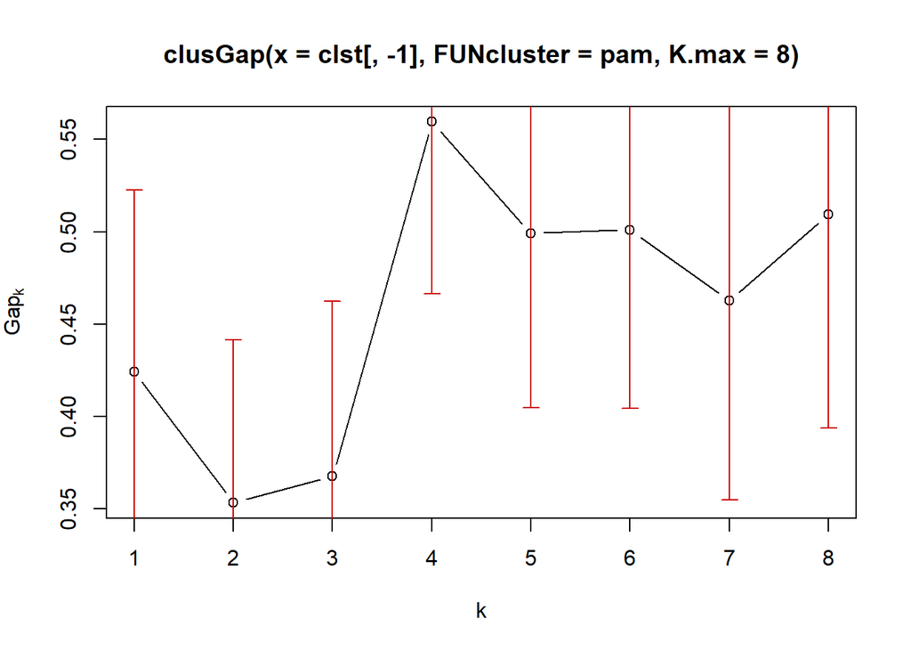

```r
clst = mh %>%
  pivot_wider(names_from = year, values_from = exports_per_gdp, id_cols = country)

cl = clusGap(clst[, -1], FUN = pam, K.max = 8)

plot(cl)
```

```r
print(cl, method = 'globalSEmax')
```

```
## Clustering Gap statistic ["clusGap"] from call:
## clusGap(x = clst[, -1], FUNcluster = pam, K.max = 8)
## B=100 simulated reference sets, k = 1..8; spaceH0="scaledPCA"
##  --> Number of clusters (method 'globalSEmax', SE.factor=1): 4
##           logW    E.logW       gap     SE.sim
## [1,] 1.9546347 2.3789528 0.4243181 0.09815022
## [2,] 1.5555906 1.9089557 0.3533651 0.08809962
## [3,] 1.2798833 1.6474662 0.3675829 0.09478920
## [4,] 0.8625000 1.4220494 0.5595494 0.09323774
## [5,] 0.7131803 1.2122404 0.4990601 0.09430659
## [6,] 0.5257621 1.0268988 0.5011367 0.09672121
## [7,] 0.3865874 0.8492654 0.4626780 0.10769615
## [8,] 0.1641049 0.6735548 0.5094499 0.11582046
```

# Final Plot

Refit the model using the identified number of clusters using `pam()`. Identify the labels for each country. Reproduce the original plot with colors of exports per GDP over countries colored by their cluster.

Print the labels `arrange()`d by group.

```r
fit = pam(clst[, -1], 4)
lbls = data.frame(country = clst$country, group = fit$clustering)

plt = left_join(mh, lbls)
```

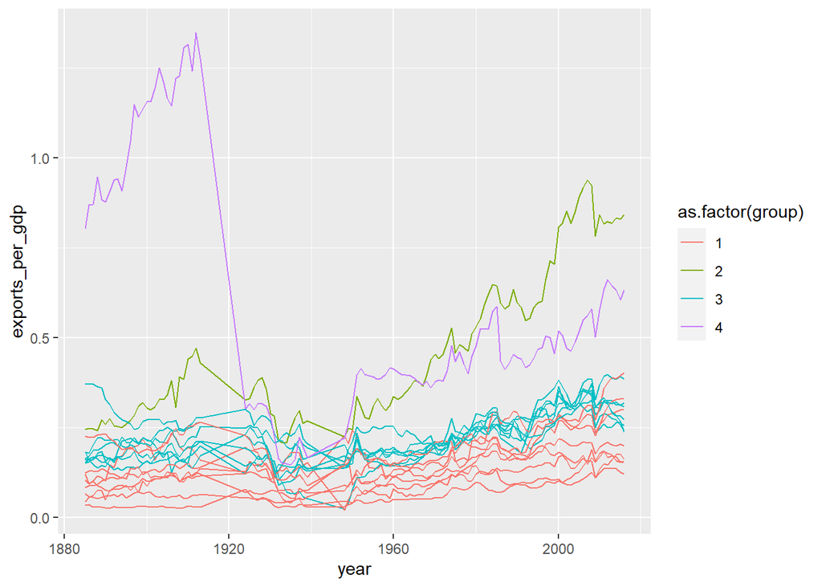

```r
ggplot(plt, aes(x = year, y = exports_per_gdp, color = as.factor(group), group = country)) +
  geom_line()
```

```r
lbls %>% arrange(group)
```

```
##        country group
## 1    Australia     1
## 2       France     1
## 3        Italy     1
## 4        Japan     1
## 5     Portugal     1
## 6        Spain     1
## 7           UK     1
## 8          USA     1
## 9      Belgium     2
## 10      Canada     3
## 11     Denmark     3
## 12     Finland     3
## 13     Germany     3
## 14      Norway     3
## 15      Sweden     3
## 16 Switzerland     3
## 17 Netherlands     4
```